# Data Science for Public Policy

Assignment 04

Author

Affiliation

Caroline Atuhaire - ca975, Troy Cheng - yc1317

Georgetown University

# 01 Data Source

[World Development Indicators](https://databank.worldbank.org/source/world-development-indicators) from World Bank

# 02 Set Up Packages

```r
# install.packages(c("readxl", "writexl")

library(readxl)
library(writexl)
library(tidyverse)
```

As the process of data cleaning was too complicated, we made it as an appendix. You can follow the code in **Appendix** and reproduce the cleaned data set we use here.

# 03 Research Question

Economic engagement goes beyond simply having a job. It depends on who is working, in which sectors, and under what conditions. While labor force participation reflects workforce involvement, sectoral shifts between agriculture, industry, and services reveal deeper economic transformations. This intrigues the question: how does economic engagement, *through labor force participation, sectoral shifts, and wage employment*, shape job stability and household consumption across different economies?

As economies move toward service-based employment, the question remains whether this shift creates stable, wage-paid jobs or perpetuates informal labor. Ultimately, for employment to drive economic stability, rising wage employment should lead to higher household consumption. This analysis examines these dynamics across China, Uganda, and the United States from 2001 to 2023, exploring whether economic growth translates into meaningful labor market improvements.

# 04 Data Story and Visualization

## Load Data

```r
data_available_clean <- read_excel("data/available_data.xlsx")
```

## Graph 1. Trends of Labor Force Participation Rate in Three Countries

Labor force participation serves as a fundamental indicator of economic engagement.

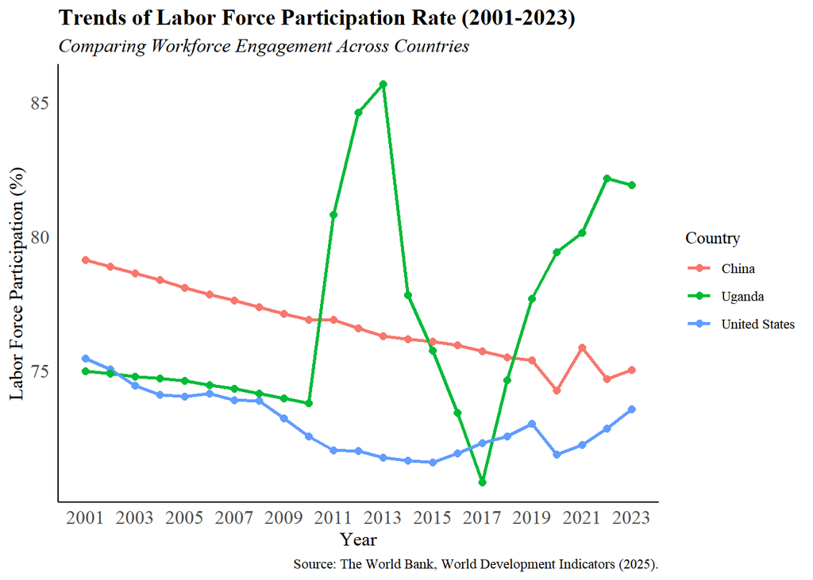

```r
ggplot(data_available_clean, aes(x = year, group = country_name, color = country_name, linetype = "solid")) +
  geom_line(aes(y = lfpr_total_15_64_milo), size = 1) +
  geom_point(aes(y = lfpr_total_15_64_milo), size = 2) +
  scale_x_continuous(breaks = seq(min(data_available_clean$year), max(data_available_clean$year), by = 2)) +
  labs(
    title = "Trends of Labor Force Participation Rate (2001-2023)",
    subtitle = "Comparing Workforce Engagement Across Countries",
    x = "Year",
    y = "Labor Force Participation (%)",
    color = "Country",
    caption = "Source: The World Bank, World Development Indicators (2025)."
  ) +
  theme_minimal() +
  theme(
    text = element_text(family = "serif"),
    panel.grid = element_blank(),
    plot.title = element_text(size = 14, face = "bold"),
    plot.subtitle = element_text(size = 12, face = "italic"),
    axis.title.x = element_text(size = 12),
    axis.title.y = element_text(size = 12),
    axis.text.x = element_text(size = 12),
    axis.text.y = element_text(size = 12),
    legend.position = "right",
    axis.line = element_line(color="black")
) +
  guides(linetype = "none")
```

As shown in the line graph, China’s participation rate steadily decreases throughout the period, maintaining a consistent downward trajectory. Uganda exhibits extreme fluctuations, with sharp increases and declines, particularly after 2010, indicating significant variability in workforce engagement. The U.S. saw a decline until 2015, followed by a slight rebound in recent years. The United States shows a gradual decline in labor force participation until around 2016, followed by a slight upward trend. Overall, China and the U.S. exhibit a gradual decline, likely due to aging populations and economic shifts.

## Graph 2. The Structure of Labor Force Participation: Employment Structures Accross Different Sectors

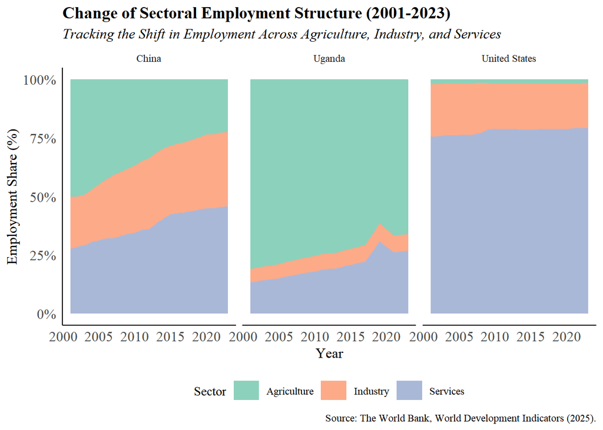

```r
data_available_clean |>
  mutate(total_employment = empl_agri + empl_industry + empl_services) |>
  pivot_longer(cols = c(empl_agri, empl_industry, empl_services),
               names_to = "sector",
               values_to = "employment_rate") |>
  mutate(employment_share = employment_rate / total_employment * 100) |>
  ggplot(aes(x = year, y = employment_share, fill = sector)) +
  geom_area(alpha = 0.75) +
  facet_wrap(~ country_name) +
  labs(
    title = "Change of Sectoral Employment Structure (2001-2023)",
    subtitle = "Tracking the Shift in Employment Across Agriculture, Industry, and Services",
    x = "Year", y = "Employment Share (%)",
    fill = "Sector",
    caption = "Source: The World Bank, World Development Indicators (2025)."
  ) +
  scale_fill_manual(values = c("empl_agri" = "#66c2a5",
                               "empl_industry" = "#fc8d62",
                               "empl_services" = "#8da0cb"),
                    labels = c("Agriculture", "Industry", "Services")) +
  scale_y_continuous(labels = scales::percent_format(scale = 1)) +
  theme_minimal() +
  theme(
    text = element_text(family = "serif"),
    panel.grid = element_blank(),
    plot.title = element_text(size = 14, face = "bold"),
    plot.subtitle = element_text(size = 12, face = "italic"),
    axis.title.x = element_text(size = 12),
    axis.title.y = element_text(size = 12),
    axis.text.x = element_text(size = 12),
    axis.text.y = element_text(size = 12),
    legend.position = "bottom",
    axis.line = element_line(color = "black"),
    legend.key.width = unit(0.8,"cm")
)
```

## Graph 3. The Relationship between Employment Rate in Service and Salaried Workers Employment Rate

As economies shift towards a service-oriented workforce, the question remains: does this growth lead to more stable, wage-paid jobs, or does informal and precarious employment persist?

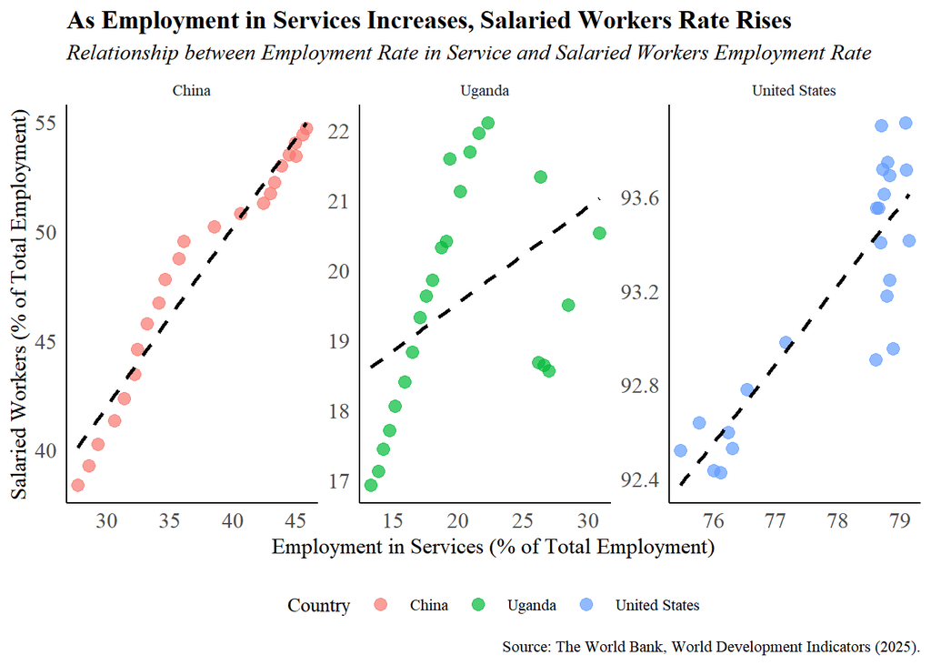

```r
ggplot(data_available_clean, aes(x = empl_services, y = wage_workers_total, color = country_name)) +
  geom_point(size = 3, alpha = 0.7) +
  geom_smooth(method = "lm", se = FALSE, linetype = "dashed", color = "black") +
  facet_wrap(~country_name, scales = "free") +
  labs(
    title = "As Employment in Services Increases, Salaried Workers Rate Rises",
    subtitle = "Relationship between Employment Rate in Service and Salaried Workers Employment Rate",
    x = "Employment in Services (% of Total Employment)",
    y = "Salaried Workers (% of Total Employment)",
    color = "Country",
    caption = "Source: The World Bank, World Development Indicators (2025)."
  ) +
    theme_minimal() +
  theme(
    text = element_text(family = "serif"),
    panel.grid = element_blank(),
    plot.title = element_text(size = 14, face = "bold"),
    plot.subtitle = element_text(size = 12, face = "italic"),
    axis.title.x = element_text(size = 12),
    axis.title.y = element_text(size = 12),
    axis.text.x = element_text(size = 12),
    axis.text.y = element_text(size = 12),
    legend.position = "bottom",
    axis.line = element_line(color = "black"),
    legend.key.width = unit(0.75,"cm")
)
```

The scatter graph shows the relationship between employment in services and the share of salaried workers across China, Uganda, and the United States. In all three countries, a higher share of service employment correlates with a greater proportion of salaried workers, suggesting a shift toward more formal employment. China exhibits a strong positive trend, indicating that service sector growth aligns with stable wage jobs. Uganda shows more variability, suggesting that many service jobs remain informal. The United States has consistently high salaried employment, reinforcing the dominance of formal jobs in a service-driven economy.